# Wine analytics Notebook

The dataset consists of 38 observations of 6 variables (small dataset)

```r
wine <- read.csv("wine.csv")
str(wine)
```

```
'data.frame':   38 obs. of  6 variables:
 $ VINT   : int  1952 1953 1954 1955 1956 1957 1958 1959 1960 1961 ...
 $ LPRICE : num  -0.999 -0.454 NA -0.808 NA ...
 $ WRAIN  : int  600 690 430 502 440 420 582 485 763 830 ...
 $ DEGREES: num  17.1 16.7 15.4 17.1 15.7 ...
 $ HRAIN  : int  160 80 180 130 140 110 187 187 290 38 ...
 $ TIME_SV: int  31 30 29 28 27 26 25 24 23 22 ...
```

```r
summary(wine)
```

```
      VINT          LPRICE           WRAIN          DEGREES          HRAIN
 Min.   :1952   Min.   :-2.289   Min.   :376.0   Min.   :14.98   Min.   : 38.0
 1st Qu.:1961   1st Qu.:-1.985   1st Qu.:510.2   1st Qu.:16.18   1st Qu.: 87.5
 Median :1970   Median :-1.509   Median :586.5   Median :16.54   Median :120.5
 Mean   :1970   Mean   :-1.452   Mean   :605.0   Mean   :16.57   Mean   :137.0
 3rd Qu.:1980   3rd Qu.:-1.052   3rd Qu.:713.5   3rd Qu.:17.09   3rd Qu.:171.0
 Max.   :1989   Max.   : 0.000   Max.   :845.0   Max.   :18.50   Max.   :292.0
                NA's   :11
    TIME_SV
 Min.   :-6.00
 1st Qu.: 3.25
 Median :12.50
 Mean   :12.50
 3rd Qu.:21.75
 Max.   :31.00
```

1954 and 1956 wine prices are not available in the dataset since they are rarely sold now. The prices form 1981 to 1989 are not available in the dataset

```r
is.na(wine)
```

```
       VINT LPRICE WRAIN DEGREES HRAIN TIME_SV
 [1,] FALSE  FALSE FALSE   FALSE FALSE   FALSE
 [2,] FALSE  FALSE FALSE   FALSE FALSE   FALSE
 [3,] FALSE   TRUE FALSE   FALSE FALSE   FALSE
 [4,] FALSE  FALSE FALSE   FALSE FALSE   FALSE
 [5,] FALSE   TRUE FALSE   FALSE FALSE   FALSE
 [6,] FALSE  FALSE FALSE   FALSE FALSE   FALSE
 [7,] FALSE  FALSE FALSE   FALSE FALSE   FALSE
 [8,] FALSE  FALSE FALSE   FALSE FALSE   FALSE
 [9,] FALSE  FALSE FALSE   FALSE FALSE   FALSE
[10,] FALSE  FALSE FALSE   FALSE FALSE   FALSE
[11,] FALSE  FALSE FALSE   FALSE FALSE   FALSE
[12,] FALSE  FALSE FALSE   FALSE FALSE   FALSE
[13,] FALSE  FALSE FALSE   FALSE FALSE   FALSE
[14,] FALSE  FALSE FALSE   FALSE FALSE   FALSE
```

[output cut: 24 more lines]

The scatter plot indicates a negative relationship but there is considerable variation that still needs to be captured. We can also plot a matrix of all scatter plots using the pairs command.

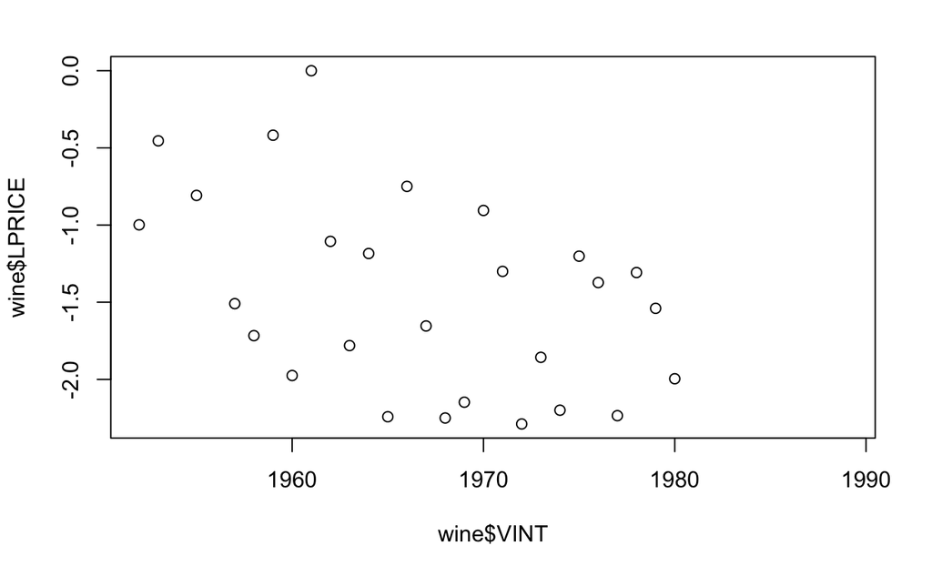

```r
plot(wine$VINT,wine$LPRICE)
```

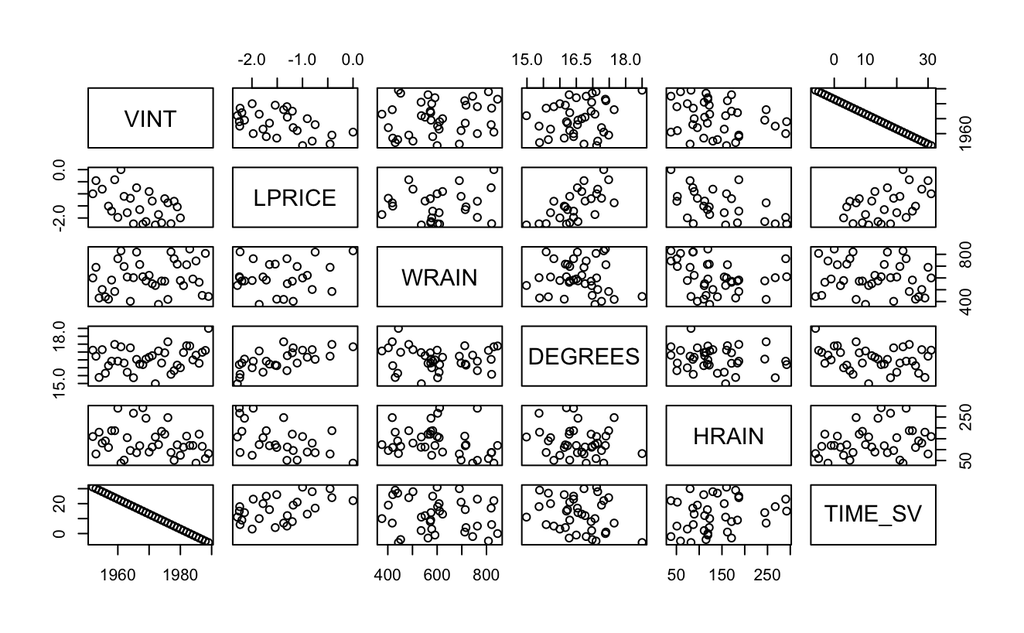

```r
pairs(wine)
```

Split the data set into a training dataset from 1952 to 1978 (drop 1954 and 1956 since prices are not observable) and we use the test set from 1979 onwards. Note that for the test set however we only have prices till 1980 (so in this case we can only use 1979 and 1980) to test the model.

```r
winetrain <- subset(wine,wine$VINT <= 1978 & !is.na(wine$LPRICE))
winetrain
```

|  | VINT | LPRICE | WRAIN | DEGREES | HRAIN | TIME_SV |
| --- | --- | --- | --- | --- | --- | --- |
| 1 | 1952 | -0.99868 | 600 | 17.1167 | 160 | 31 |
| 2 | 1953 | -0.45440 | 690 | 16.7333 | 80 | 30 |
| 4 | 1955 | -0.80796 | 502 | 17.1500 | 130 | 28 |
| 6 | 1957 | -1.50926 | 420 | 16.1333 | 110 | 26 |
| 7 | 1958 | -1.71655 | 582 | 16.4167 | 187 | 25 |
| 8 | 1959 | -0.41800 | 485 | 17.4833 | 187 | 24 |
| 9 | 1960 | -1.97491 | 763 | 16.4167 | 290 | 23 |
| 10 | 1961 | 0.00000 | 830 | 17.3333 | 38 | 22 |
| 11 | 1962 | -1.10572 | 697 | 16.3000 | 52 | 21 |
| 12 | 1963 | -1.78098 | 608 | 15.7167 | 155 | 20 |

[output cut: 15 more lines]

```r
winetest <- subset(wine,wine$VINT > 1978)
winetest
```

|  | VINT | LPRICE | WRAIN | DEGREES | HRAIN | TIME_SV |
| --- | --- | --- | --- | --- | --- | --- |
| 28 | 1979 | -1.53960 | 717 | 16.1667 | 122 | 4 |
| 29 | 1980 | -1.99582 | 578 | 16.0000 | 74 | 3 |
| 30 | 1981 | NA | 535 | 16.9667 | 111 | 2 |
| 31 | 1982 | NA | 712 | 17.4000 | 162 | 1 |
| 32 | 1983 | NA | 845 | 17.3833 | 119 | 0 |
| 33 | 1984 | NA | 591 | 16.5000 | 119 | -1 |
| 34 | 1985 | NA | 744 | 16.8000 | 38 | -2 |
| 35 | 1986 | NA | 563 | 16.2833 | 171 | -3 |
| 36 | 1987 | NA | 452 | 16.9833 | 115 | -4 |
| 37 | 1988 | NA | 808 | 17.1000 | 59 | -5 |

[output cut: 1 more lines]

One variable regression - lm() is the basic command to fit a linear model to the data.

```r
?lm
model1  <- lm(LPRICE~VINT,data=winetrain)
model1
```

```
Call:
lm(formula = LPRICE ~ VINT, data = winetrain)

Coefficients:
(Intercept)         VINT
   72.99301     -0.03786
```

```r
summary(model1)
```

```
Call:
lm(formula = LPRICE ~ VINT, data = winetrain)

Residuals:
     Min       1Q   Median       3Q      Max
-0.84574 -0.46266 -0.09462  0.48752  1.24478

Coefficients:
            Estimate Std. Error t value Pr(>|t|)
(Intercept) 72.99301   30.98789   2.356   0.0274 *
VINT        -0.03786    0.01576  -2.402   0.0248 *
---
Signif. codes:  0 '***' 0.001 '**' 0.01 '*' 0.05 '.' 0.1 ' ' 1

Residual standard error: 0.594 on 23 degrees of freedom
Multiple R-squared:  0.2005,    Adjusted R-squared:  0.1657
F-statistic: 5.768 on 1 and 23 DF,  p-value: 0.0248
```

Plot the best fit line with a slope of -0.0378.

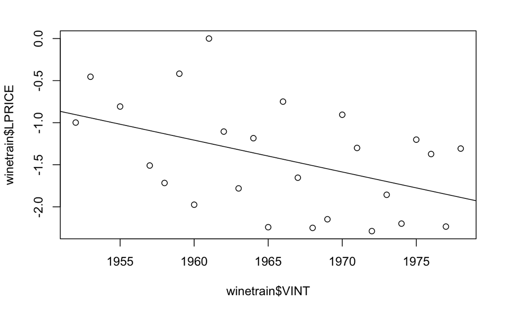

```r
plot(winetrain$VINT,winetrain$LPRICE)
?abline
abline(model1)
```

Evaluate the sum of squared errors and total sum of squares

```r
model1$residuals
```

```
          1           2           4           6           7           8           9
-0.09461844  0.48751867  0.20967287 -0.41591292 -0.58534581  0.75106129 -0.76799160
         10          11          12          13          14          15          16
 1.24477550  0.17691260 -0.46049029  0.17399681 -0.84573608  0.68463102 -0.18196187
         17          18          19          20          21          22          23
-0.74040477 -0.60020767  0.68004944  0.32303654 -0.62758635 -0.15793925 -0.46266215
         24          25          26          27
 0.57309496  0.43999206 -0.38454083  0.58065627
```

```r
sse1 <- sum(model1$residuals^2)
sst1 <- sum((winetrain$LPRICE-mean(winetrain$LPRICE))^2)
1 - sse1/sst1
```

```
[1] 0.2004897
```

```r
summary(model1)
```

```
Call:
lm(formula = LPRICE ~ VINT, data = winetrain)

Residuals:
     Min       1Q   Median       3Q      Max
-0.84574 -0.46266 -0.09462  0.48752  1.24478

Coefficients:
            Estimate Std. Error t value Pr(>|t|)
(Intercept) 72.99301   30.98789   2.356   0.0274 *
VINT        -0.03786    0.01576  -2.402   0.0248 *
---
Signif. codes:  0 '***' 0.001 '**' 0.01 '*' 0.05 '.' 0.1 ' ' 1

Residual standard error: 0.594 on 23 degrees of freedom
Multiple R-squared:  0.2005,    Adjusted R-squared:  0.1657
F-statistic: 5.768 on 1 and 23 DF,  p-value: 0.0248
```

The result indicates that older the wine, greater is the value but there is still significant variation.

One variable regression - continued

```r
model2  <- lm(LPRICE~WRAIN,data=winetrain)
summary(model2)
```

```
Call:
lm(formula = LPRICE ~ WRAIN, data = winetrain)

Residuals:
     Min       1Q   Median       3Q      Max
-0.95348 -0.65439  0.04172  0.43136  1.27550

Coefficients:
              Estimate Std. Error t value Pr(>|t|)
(Intercept) -1.8331730  0.6286160  -2.916  0.00777 **
WRAIN        0.0006719  0.0010155   0.662  0.51479
---
Signif. codes:  0 '***' 0.001 '**' 0.01 '*' 0.05 '.' 0.1 ' ' 1

Residual standard error: 0.6581 on 23 degrees of freedom
Multiple R-squared:  0.01868,   Adjusted R-squared:  -0.02399
F-statistic: 0.4377 on 1 and 23 DF,  p-value: 0.5148
```

```r
model3  <- lm(LPRICE~HRAIN,data=winetrain)
summary(model3)
```

```
Call:
lm(formula = LPRICE ~ HRAIN, data = winetrain)

Residuals:
    Min      1Q  Median      3Q     Max
-1.1116 -0.3228 -0.1008  0.3691  1.1977

Coefficients:
             Estimate Std. Error t value Pr(>|t|)
(Intercept) -0.695162   0.249152   -2.79  0.01040 *
HRAIN       -0.004923   0.001506   -3.27  0.00337 **
---
Signif. codes:  0 '***' 0.001 '**' 0.01 '*' 0.05 '.' 0.1 ' ' 1

Residual standard error: 0.5489 on 23 degrees of freedom
Multiple R-squared:  0.3173,    Adjusted R-squared:  0.2877
F-statistic: 10.69 on 1 and 23 DF,  p-value: 0.003366
```

```r
model4  <- lm(LPRICE~DEGREES,data=winetrain)
summary(model4)
```

```
Call:
lm(formula = LPRICE ~ DEGREES, data = winetrain)

Residuals:
     Min       1Q   Median       3Q      Max
-0.78449 -0.23885 -0.03727  0.38994  0.90320

Coefficients:
            Estimate Std. Error t value Pr(>|t|)
(Intercept) -11.9114     2.4935  -4.777 8.12e-05 ***
DEGREES       0.6351     0.1509   4.208 0.000335 ***
---
Signif. codes:  0 '***' 0.001 '**' 0.01 '*' 0.05 '.' 0.1 ' ' 1

Residual standard error: 0.4993 on 23 degrees of freedom
Multiple R-squared:  0.435, Adjusted R-squared:  0.4105
F-statistic: 17.71 on 1 and 23 DF,  p-value: 0.0003351
```

Two variables - The effect of DEGREES and HRAIN on LPRICE.

```r
plot(winetrain$DEGREES,winetrain$HRAIN)
abline(h=mean(winetrain$HRAIN))
```

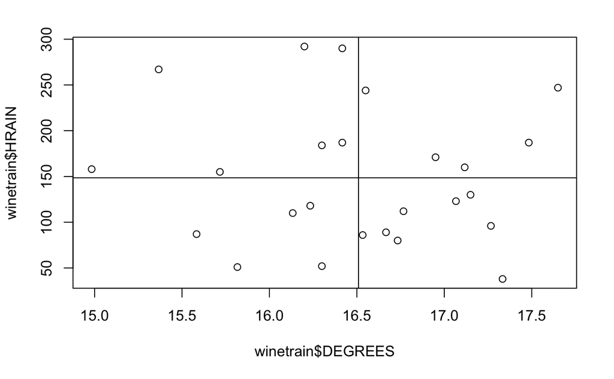

```r
abline(v=mean(winetrain$DEGREES))
```

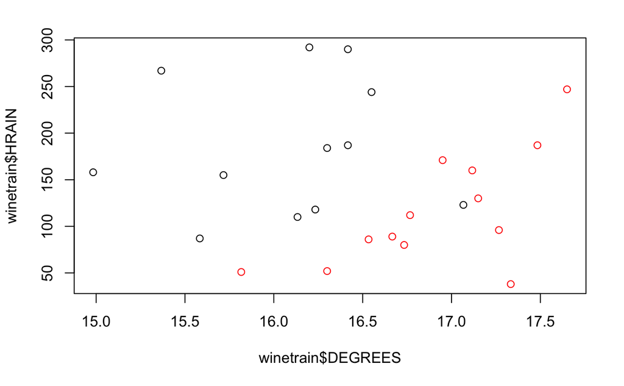

```r
plot(winetrain$DEGREES,winetrain$HRAIN,col=ifelse(winetrain$LPRICE>=mean(winetrain$LPRICE),"red","black"))
```

The figure indicates that hot and dry summers produce wines that obtain higher prices while cooler summers with more rain gives lower priced wines. 1961 is an year where an extremely high quality wine was produced.

Two variable regression

```r
model5  <- lm(LPRICE~DEGREES+HRAIN,data=winetrain)
summary(model5)
```

```
Call:
lm(formula = LPRICE ~ DEGREES + HRAIN, data = winetrain)

Residuals:
     Min       1Q   Median       3Q      Max
-0.88319 -0.19599  0.06181  0.15379  0.59724

Coefficients:
             Estimate Std. Error t value Pr(>|t|)
(Intercept) -10.69628    1.85444  -5.768 8.40e-06 ***
DEGREES       0.60261    0.11128   5.415 1.94e-05 ***
HRAIN        -0.00457    0.00101  -4.525 0.000167 ***
---
Signif. codes:  0 '***' 0.001 '**' 0.01 '*' 0.05 '.' 0.1 ' ' 1

Residual standard error: 0.3674 on 22 degrees of freedom
Multiple R-squared:  0.7074,    Adjusted R-squared:  0.6808
F-statistic: 26.59 on 2 and 22 DF,  p-value: 1.348e-06
```

LPRICE = -10.69 + 0.602*DEGREES - 0.0045*HRAIN. Both variables are extremely significant in the fit with R^2 = 0.7 and adjusted R^2 = 0.68.

Multiple linear regression - Note tha TIME_SV coefficients are not defined as it is perfectly correlated with the VINT variable (perfect multicollinearity). We drop the variable and redo the regression. High correlation (in absolute value) between independent variables is not good (indication of multicollinearity) while high correlation (in absolute value) between dependent and independent variables is good.

```r
model6  <- lm(LPRICE~.,data=winetrain)
summary(model6)
```

```
Call:
lm(formula = LPRICE ~ ., data = winetrain)

Residuals:
     Min       1Q   Median       3Q      Max
-0.45473 -0.24276  0.00753  0.19770  0.53640

Coefficients: (1 not defined because of singularities)
              Estimate Std. Error t value Pr(>|t|)
(Intercept) 35.5297567 16.4435924   2.161 0.043028 *
VINT        -0.0239302  0.0080969  -2.955 0.007821 **
WRAIN        0.0010756  0.0005073   2.120 0.046684 *
DEGREES      0.6072099  0.0987030   6.152  5.2e-06 ***
HRAIN       -0.0039715  0.0008538  -4.652 0.000154 ***
TIME_SV             NA         NA      NA       NA
---
Signif. codes:  0 '***' 0.001 '**' 0.01 '*' 0.05 '.' 0.1 ' ' 1

Residual standard error: 0.295 on 20 degrees of freedom
Multiple R-squared:  0.8286,    Adjusted R-squared:  0.7943
F-statistic: 24.17 on 4 and 20 DF,  p-value: 2.036e-07
```

```r
cor(winetrain)
```

```
               VINT     LPRICE       WRAIN     DEGREES       HRAIN     TIME_SV
VINT     1.00000000 -0.4477608  0.01697002 -0.24691585  0.02800907 -1.00000000
LPRICE  -0.44776081  1.0000000  0.13666199  0.65955892 -0.56332212  0.44776081
WRAIN    0.01697002  0.1366620  1.00000000 -0.32109061 -0.27544085 -0.01697002
DEGREES -0.24691585  0.6595589 -0.32109061  1.00000000 -0.06449593  0.24691585
HRAIN    0.02800907 -0.5633221 -0.27544085 -0.06449593  1.00000000 -0.02800907
TIME_SV -1.00000000  0.4477608 -0.01697002  0.24691585 -0.02800907  1.00000000
```

```r
model7  <- lm(LPRICE~VINT+WRAIN+DEGREES+HRAIN,data=winetrain)
summary(model7)
```

```
Call:
lm(formula = LPRICE ~ VINT + WRAIN + DEGREES + HRAIN, data = winetrain)

Residuals:
     Min       1Q   Median       3Q      Max
-0.45473 -0.24276  0.00753  0.19770  0.53640

Coefficients:
              Estimate Std. Error t value Pr(>|t|)
(Intercept) 35.5297567 16.4435924   2.161 0.043028 *
VINT        -0.0239302  0.0080969  -2.955 0.007821 **
WRAIN        0.0010756  0.0005073   2.120 0.046684 *
DEGREES      0.6072099  0.0987030   6.152  5.2e-06 ***
HRAIN       -0.0039715  0.0008538  -4.652 0.000154 ***
---
Signif. codes:  0 '***' 0.001 '**' 0.01 '*' 0.05 '.' 0.1 ' ' 1

Residual standard error: 0.295 on 20 degrees of freedom
Multiple R-squared:  0.8286,    Adjusted R-squared:  0.7943
F-statistic: 24.17 on 4 and 20 DF,  p-value: 2.036e-07
```

```r
model7a <- lm(LPRICE~WRAIN+DEGREES+HRAIN,data=winetrain)
summary(model7a)
```

```
Call:
lm(formula = LPRICE ~ WRAIN + DEGREES + HRAIN, data = winetrain)

Residuals:
     Min       1Q   Median       3Q      Max
-0.67475 -0.12957  0.01975  0.20754  0.63848

Coefficients:
              Estimate Std. Error t value Pr(>|t|)
(Intercept) -1.280e+01  2.037e+00  -6.282 3.13e-06 ***
WRAIN        1.177e-03  5.920e-04   1.987 0.060085 .
DEGREES      6.810e-01  1.117e-01   6.097 4.75e-06 ***
HRAIN       -3.948e-03  9.987e-04  -3.953 0.000726 ***
---
Signif. codes:  0 '***' 0.001 '**' 0.01 '*' 0.05 '.' 0.1 ' ' 1

Residual standard error: 0.345 on 21 degrees of freedom
Multiple R-squared:  0.7537,    Adjusted R-squared:  0.7185
F-statistic: 21.42 on 3 and 21 DF,  p-value: 1.359e-06
```

R^2 = 0.828 and adjusted R^2 = 0.794. The coefficients indicate that high quality wines correlate strongly in a positive manner with summer temperatures, negatively correlate with harvest rain and positively correlate with winter rain. The result indicates that 80% of the variaion can be explained by including the weather variables in comparison to 20% with only the vintage year. We can run the model by dropping VINT but this decreases R^2 to 0.75 and adjusted R^2 to 0.71.

We can obtain confidence intervals for the estimates using the confint command.

```r
model4$coefficients
```

```
(Intercept)     DEGREES
-11.9113839   0.6350888
```

```r
model4$residuals
```

```
          1           2           4           6           7           8           9          10
 0.04207953  0.82985257  0.21165107  0.15604585 -0.23122831  0.38993597 -0.48958831  0.90319929
         11          12          13          14          15          16          17          18
 0.45371655  0.14890384 -0.23885379 -0.08977508  0.66184033 -0.05208303 -0.62723457 -0.74717565
         19          20          21          22          23          24          25          26
 0.42110949 -0.03726939  0.10686797 -0.78448603 -0.64014345 -0.05505117 -0.67057333 -0.22042531
         27
 0.55868496
```

```r
confint(model4)
```

```
                 2.5 %     97.5 %
(Intercept) -17.069618 -6.7531495
DEGREES       0.322896  0.9472816
```

```r
confint(model4,level=0.99)
```

```
                  0.5 %    99.5 %
(Intercept) -18.9115253 -4.911243
DEGREES       0.2114179  1.058760
```

Predictions - The predict function helps predict the outcome of the model on values in the test set. The test R-squared for model 7 is 0.79.

```r
str(winetest)
```

```
'data.frame':   11 obs. of  6 variables:
 $ VINT   : int  1979 1980 1981 1982 1983 1984 1985 1986 1987 1988 ...
 $ LPRICE : num  -1.54 -2 NA NA NA ...
 $ WRAIN  : int  717 578 535 712 845 591 744 563 452 808 ...
 $ DEGREES: num  16.2 16 17 17.4 17.4 ...
 $ HRAIN  : int  122 74 111 162 119 119 38 171 115 59 ...
 $ TIME_SV: int  4 3 2 1 0 -1 -2 -3 -4 -5 ...
```

```r
wineprediction7 <- predict(model7,newdata=winetest)
wineprediction7
```

```
        28         29         30         31         32         33         34         35         36
-1.7247744 -1.8087984 -1.4389334 -1.2119306 -0.9321766 -1.7656490 -1.1211635 -2.1817252 -1.6775926
        37         38
-1.0253562 -0.6831185
```

```r
sse7 <- sum((wineprediction7[1:2]-winetest$LPRICE[1:2])^2)
sse7
```

```
[1] 0.06926665
```

```r
sst <-sum((winetest$LPRICE[1:2]-mean(winetrain$LPRICE))^2)
sst
```

```
[1] 0.3369311
```

```r
1 - sse7/sst
```

```
[1] 0.7944189
```

```r
wineprediction4 <- predict(model4,newdata=winetest)
sse4 <- sum((wineprediction4[1:2]-winetest$LPRICE[1:2])^2)
1-sse4/sst
```

```
[1] 0.7881924
```

```r
wineprediction5 <- predict(model5,newdata=winetest)
sse5 <- sum((wineprediction5[1:2]-winetest$LPRICE[1:2])^2)
1-sse5/sst
```

```
[1] -0.08201462
```

We use the training test mean to compute the total sum of squares for computing the test R^2 values. The results indicate that better R^2 in the training set does not necessarily indicate better R^2 in test set (this can also be negative).

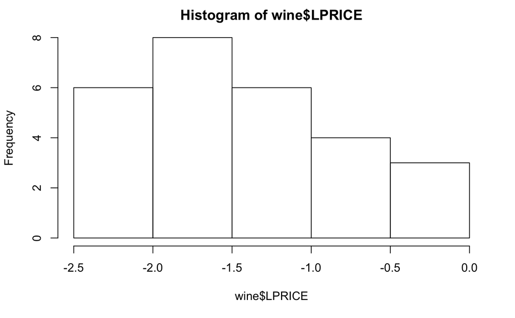

```r
hist(wine$LPRICE)
```

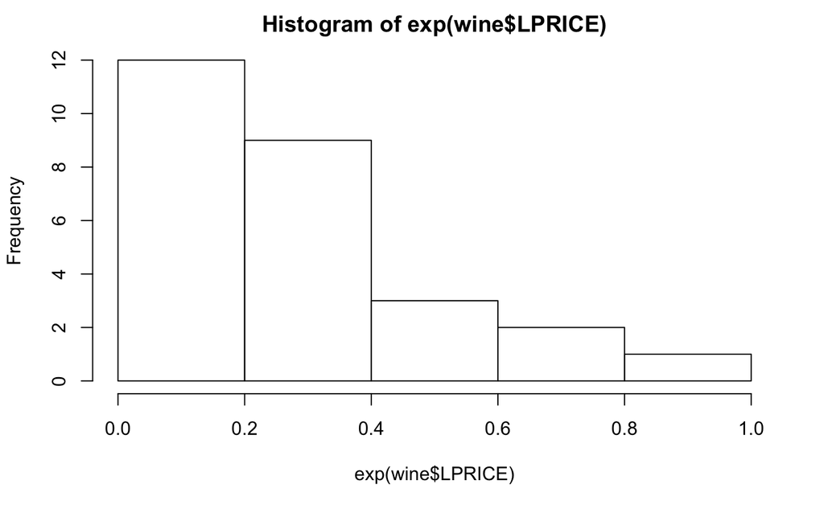

```r
hist(exp(wine$LPRICE))
```

The use of logarithms for prices is fairly common in the economics literature - partly jusified by skewed values in some datasets dealing with numbers such as salaries and partly justified by functional relations such as y = exp(a+bx) which gives log y = a+bx. Such transformations need to be justified and is sometime specific to domains. Even if one directly uses prices in the regression, similar insights are found in this dataset.